# Semana 09- code sessions

Controles sintéticos

Carlos Daboín

June, 2022

```r
library(tidyverse)
library(haven)
library(Synth)
library(devtools)
library(SCtools)

texas <- read_dta("https://raw.github.com/scunning1975/mixtape/master/texas.dta") %>%
  as.data.frame(.)
```

# Construcción de prisiones y encarcelamiento de minorías

Hoy replicaremos los resultados de “Studying the Effect of Incarceration Socks to Drug Markets”, un working paper de de S. Cunningham y S. Kang (2019).

- En 1980, el Departamento de Correccionales de Texas (TDC por sus siglas en inglés), perdio una demanda civil que lo forzaba a reducir la cantidad de prisioneros por celda para hacerlas mas habitables. Enfrentaron dos opciones: Construir mas prisiones o dejar a mas presos en libertad condicional.
- Optaron por reducir el hacinamiento otorgando mas sentencias de libertad condicional en el corto plazo.
- En 1993 se aprueban 1 millardo de dólares para la construcción de prisiones en Texas. Se duplica capacidad carcelaria en tres años.
- ¿Cúal fue el efecto del incremento de la capacidad carcelaria en la tasa de encarcelación de hombres Afor-Americanos?

Démosle un vistazo a data:

```r
head(texas)
```

```
##   statefip year race bmprison wmprison  bmpop   wmpop error     crack alcohol
## 1        1 1985    2     6227     4210 464428 1427743     0 0.2174378    1.90
## 2        1 1986    1     6657     4423 465387 1434773     0 0.2768753    1.90
## 3        1 1987    1     7281     4803 467545 1442894     0 0.2113712    1.89
## 4        1 1988    1     7244     4605 468281 1445048     0 0.5597811    1.89
## 5        1 1989    1     8056     4998 468893 1445678     0 0.7218242    1.87
## 6        1 1990    1     9282     5421 470480 1450374     0 0.5094361    1.92
##   income       ur poverty    black perc1519 aidscapita   state parole probation
## 1  11566 8.616667    20.6 25.86634 8.461768  0.6795045 Alabama   2425     16520
## 2  12164 9.083334    23.8 25.82727 8.473580  0.8516917 Alabama   3038     21371
## 3  12826 7.650000    21.3 25.77733 8.397089  1.9672137 Alabama   3456     23406
## 4  13698 6.916667    19.3 25.73439 8.280076  2.7581367 Alabama   4701     25301
## 5  14865 6.616667    18.9 25.69405 8.088959  3.8459067 Alabama   5724     25519
## 6  15723 6.333333    19.2 25.59587 7.868362  4.3703108 Alabama   5970     27686
##   capacity_rated capacity_operational capacity_design  bmprate  wmprate
## 1           9787                 9787            9787 1340.789 294.8710
## 2          10374                10374           10374 1430.422 308.2718
## 3          11107                11107           11107 1557.283 332.8727
## 4          11162                11162           11162 1546.934 318.6745
## 5          11162                11662           11662 1718.089 345.7202
## 6          13782                13782           13782 1972.879 373.7657
```

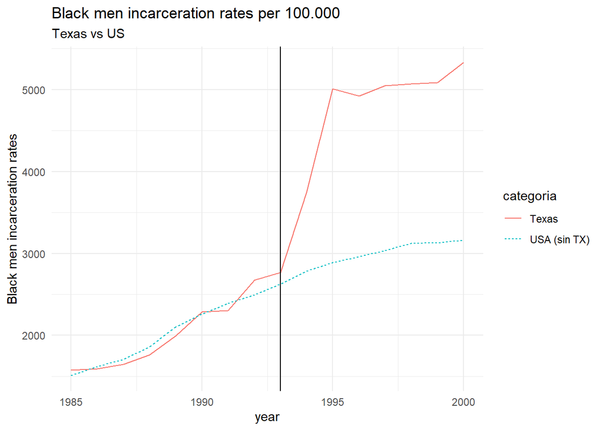

```r
texas %>%
  # agrupemos los datos segun: Texas - todo lo demas
  # creamos la variable Texas- todo lo demas con
  mutate(categoria=ifelse(state=="Texas","Texas","USA (sin TX)")) %>%
  # usamos group by por ano y categoria
  group_by(year,categoria) %>%
  # calculamos la poblacion total y la cantidad de prisioneros total por cruce ano-categoria
  summarise(bmprison=sum(bmprison),
            bmpop=sum(bmpop)) %>%
  # graficamos la tasa de encarcelacion por cada 100.000 habitantes
  ggplot(aes(x=year, y=bmprison/bmpop*100000, group=categoria))+
  geom_line(aes(color=categoria, linetype=categoria))+
  geom_vline(xintercept = 1993)+
  theme_minimal()+
  labs(title = "Black men incarceration rates per 100.000",
       subtitle = "Texas vs US",
       y="Black men incarceration rates")
```

# Manos en la data

```r
# Prepara el objeto que servira como base para el analisis de controles sinteticos
dataprep_out <- Synth::dataprep(
  foo = texas,                          # data
  predictors = c("poverty", "income"),  # predictores
  predictors.op = "mean",               # promedio
  time.predictors.prior = 1985:1993,    # Período para estimacion
  special.predictors = list(            # segmentacion de la prediccion por variable
    list("bmprison", c(1988, 1990:1992), "mean"), # fijate que controlamos por pre-treatment outcomes (more or less)
    list("alcohol", 1990, "mean"),
    list("aidscapita", 1990:1991, "mean"),
    list("black", 1990:1992, "mean"),
    list("perc1519", 1990, "mean")),
  dependent = "bmprison",               # variable dependiente
  unit.variable = "statefip",           # unidad en el panel de datos
  unit.names.variable = "state",
  time.variable = "year",               # variable de tiempo en el panel de datos
  treatment.identifier = 48,            # categoria de refeerencia
  controls.identifier = c(1,2,4:6,8:13,15:42,44:47,49:51,53:56), # ids de los estados control.
  time.optimize.ssr = 1985:1993, # Período para la optimización.
  time.plot = 1985:2000          # Período completo para la figura
)

## Corre el comando synth para crear el control sintético
synth_out <- Synth::synth(dataprep_out)
```

```
##
## X1, X0, Z1, Z0 all come directly from dataprep object.
##
##
## ****************
##  searching for synthetic control unit
##
##
## ****************
## ****************
## ****************
##
## MSPE (LOSS V): 2015107
##
## solution.v:
##  0.07154915 0.02736536 0.8923763 5.5e-09 2.42e-08 0.008709159 7.6e-09
##
## solution.w:
##  3.1624e-06 2.409e-07 2.1267e-06 1.84496e-05 0.3414498 5.67e-07 2.118e-07 2.353e-07 5.36e-08 0.2981352 3.819e-07 2.736e-07 1.27466e-05 8.934e-07 1.9113e-06 1.6149e-06 8.583e-07 1.13756e-05 0.3599649 1.8153e-06 2.789e-07 3.058e-07 4.3669e-06 5.491e-07 7.4e-09 1.5586e-06 1.03716e-05 9.868e-07 4.019…
```

```r
## Veamos los pesos mas altos (top 5)

# extraigo los pesos del objeto synth_out
pesos<-round(synth_out$solution.w*100,2)
fip<-as.numeric(dimnames(synth_out$solution.w)[[1]]) # los pesos tienen un atributo, en el panel de objetos a la derecha podemos darnos cuenta de eso

# creamos una pequena tabla juntando dos vectores en un data.frame
data.frame(statefip=fip, pesos) %>%
  top_n(5,w.weight) %>%
  left_join(distinct(texas,state,statefip))
```

```
##   statefip w.weight         state
## 1        6    34.14    California
## 2       12    29.81       Florida
## 3       22    36.00     Louisiana
## 4       49     0.03          Utah
## 5       54     0.01 West Virginia
```

```r
## Capturemos la diferencia entre Texas y Texas sintética
gaps <- dataprep_out$Y1plot -   (dataprep_out$Y0plot %*% synth_out$solution.w)
# Y1plot: tasa de encarcelamiento de Texas
# Control sintético: Producto matricial entre tasa de encarcelamiento de cada estado y el vector de pesos.
# Resulta en un Promedio ponderado
gaps
```

```
##               48
## 1985  1872.28153
## 1986   370.83546
## 1987  -397.58786
## 1988 -1328.33871
## 1989 -1378.36745
## 1990   -78.96782
## 1991  -735.44034
## 1992  2357.33563
## 1993  2136.91488
## 1994 11980.50029
## 1995 25281.10022
## 1996 24294.38654
## 1997 25421.51049
## 1998 25074.59039
## 1999 25702.35123
## 2000 26159.95646
```

## Visualizando el efecto

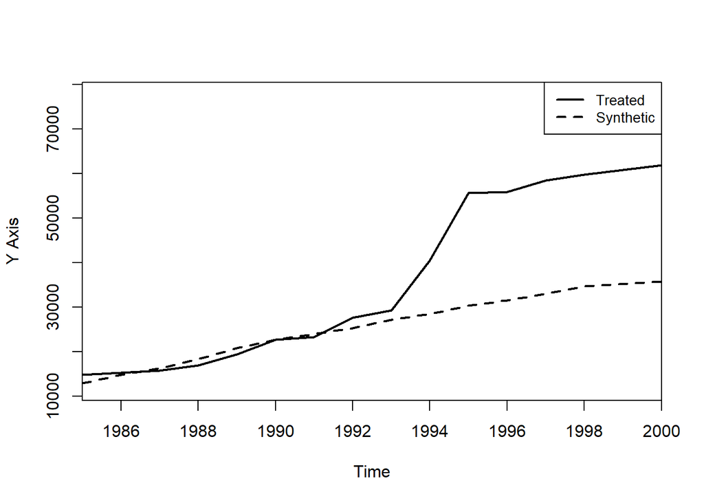

```r
# Comparacion en niveles: Texas vs Texas sintetica
path.plot(synth_out, dataprep_out)
```

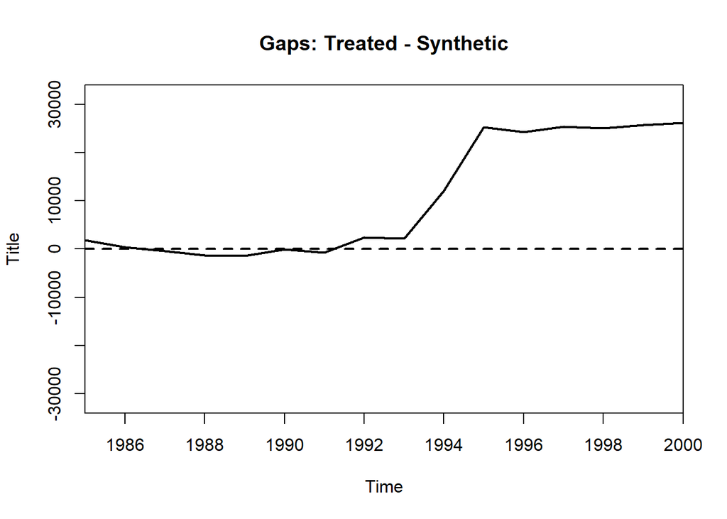

```r
# Visualizacion de brecha
gaps.plot(synth_out, dataprep_out)
```

# Placebo tests: Probemos que las diferencias son significativas

Nuestra prueba consiste en asignarle el tratamiento a cada estado y reestimar el modelo. Texas siempre sera parte del pool de donantes (un posible estado de control).

Como vimos antes, podemos comparar las diferencias entre la tasa de encarcelacion de afroamericanos entre Texas y el control sintético antes y después del tratamiento con el Root Mean Squared Prediction Error (RMSPE) pre y post-tratamiento. Si RMSPE el post-tratamiento es relativamente mayor, sabemos que el tratamiento causó diferencias importantes.

$$R M S P E=\left(\frac{1}{T-T_{0}} \sum_{t=T_{0}+t}^{T}\left(Y_{1
t}-\sum_{j=2}^{J+1} w_{j}^{*} Y_{j t}\right)^{2}\right)^{\frac{1}{2}}$$

Bueno: Eso mismo hay que hacerlo en cada iteración. Al final de las simulaciones, ordenaremos todos los ratios entre RMSPE pre y RMSPE post y los ordenaremos de menor a mayor. Después calcularemos el p-valor, que es simplemente una medida de que tan extremo es el valor del experimento real $p=\frac{R A N K}{T O T A L}$

```r
## Compara predictibilidad antes y después del tratamientro entre Texas y placebos
ratio <- mspe.test(placebos)

ratio$test %>%
  arrange(desc(MSPE.ratios)) # ranking the MSPE post/MSPE pre
```

[output not shown]

```
##    MSPE.ratios                 unit
## 1  283.0638096                Texas
## 2  246.4875272            Wisconsin
## 3  216.4871177              Georgia
## 4  130.6264727         Pennsylvania
## 5  106.4493756             Kentucky
## 6   85.1913775             Virginia
## 7   84.5523378          Mississippi
## 8   82.7915404             Delaware
## 9   76.0685962            Tennessee
## 10  65.9106167 District of Columbia
## 11  55.3939905            Louisiana
## 12  38.0690968             Maryland
## 13  29.8131091              Alabama
## 14  29.1285060        Massachusetts
```

[output cut: 37 more lines]

```r
ratio$p.val # p valor
```

```
## [1] 0.01960784
```

Un vistazo final

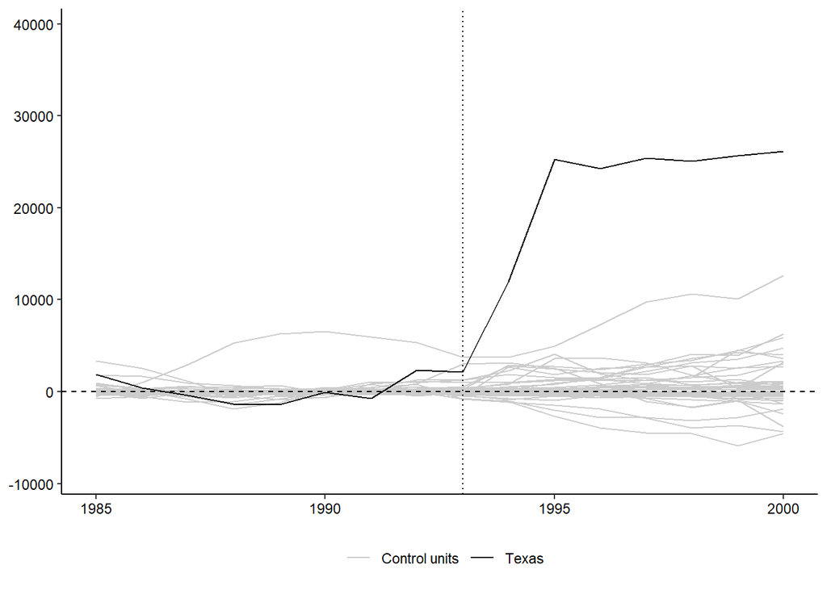

```r
plot_placebos(placebos)
```

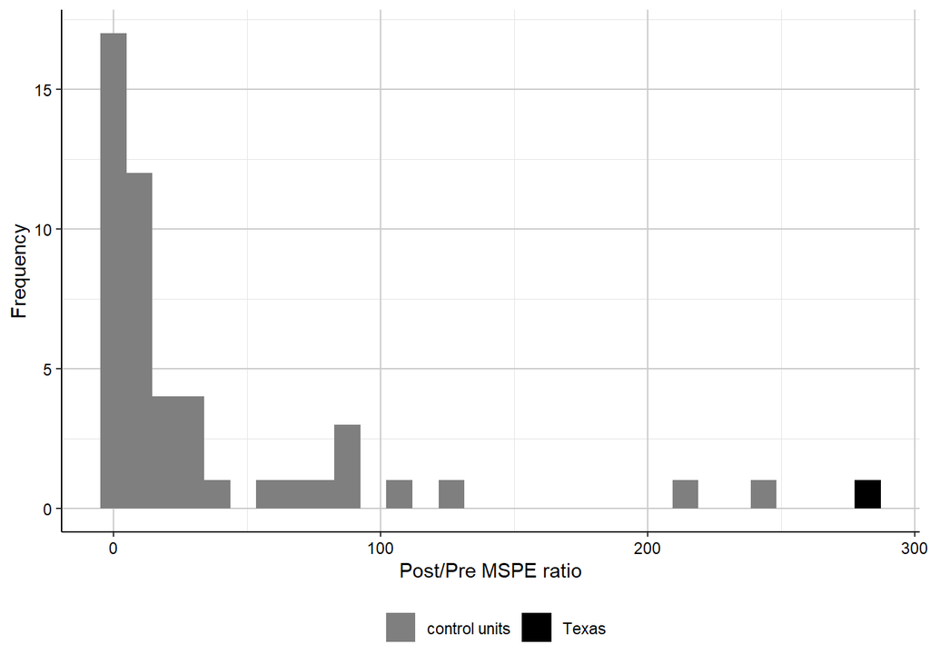

```r
mspe.plot(placebos, discard.extreme = TRUE, mspe.limit = 1, plot.hist = TRUE)
```